# Predição de Votação de Deputados

Diego Takei

4 de novembro de 2018

Inicialmente, obtenho os dados de teste e treino, filtrando as variáveis de pouca importância (categóricas) dos dados de treino.

```r
dadosIniciais <- read.csv("train.csv")
teste <- read.csv("test.csv") %>%
  mutate(comites = recursos_de_outros_candidatos.comites)
dadosFiltrados <- dadosIniciais %>%
  mutate(comites = recursos_de_outros_candidatos.comites) %>%
  select(-sequencial_candidato, -uf, -partido, - estado_civil, -ano, -recursos_de_outros_candidatos.comites)
```

### Questão 1: Usando todas as variáveis disponíveis, tune (usando validação cruzada): (i) um modelo de regressão Ridge, (ii) um modelo de regressão Lasso e (iii) um modelo KNN.

#### 1) Modelo Ridge

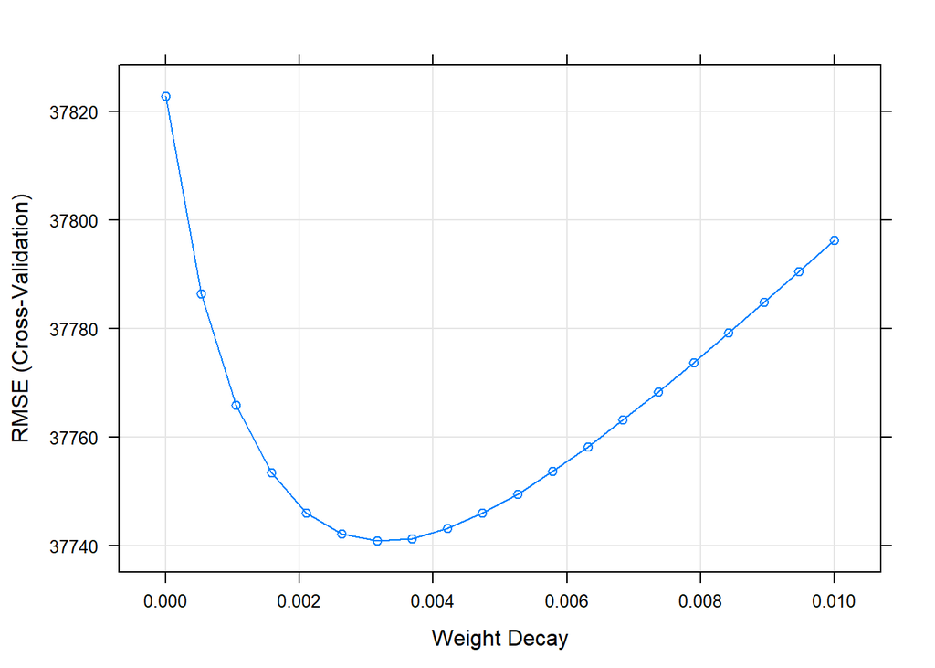

```r
lambdas <- expand.grid(lambda = seq(10^-2, 10^-11, length=20))
crossValidation <- trainControl(method = "cv", number = 10)

ridgeModel <- train(votos ~ media_despesa + total_despesa + quantidade_fornecedores + quantidade_despesas + recursos_de_partido_politico + recursos_proprios + recursos_de_pessoas_juridicas + recursos_de_pessoas_fisicas + comites + media_receita + total_receita + quantidade_doadores + quantidade_doacoes, data = dadosFiltrados,
     method = "ridge",tuneGrid = lambdas, preProc = c("center", "scale"),trControl = crossValidation)

plot(ridgeModel)
```

```r
ridgeModel
```

```
## Ridge Regression
##
## 7476 samples
##   13 predictor
##
## Pre-processing: centered (13), scaled (13)
## Resampling: Cross-Validated (10 fold)
## Summary of sample sizes: 6728, 6728, 6729, 6729, 6728, 6728, ...
## Resampling results across tuning parameters:
##
##   lambda        RMSE      Rsquared   MAE
##   1.000000e-11  37822.83  0.4058595  16916.42
##   5.263158e-04  37786.38  0.4064154  16914.88
##   1.052632e-03  37765.95  0.4067640  16915.28
##   1.578947e-03  37753.40  0.4069967  16915.85
##   2.105263e-03  37746.02  0.4071498  16916.34
##   2.631579e-03  37742.19  0.4072463  16916.80
##   3.157895e-03  37740.85  0.4073017  16917.45
##   3.684211e-03  37741.33  0.4073266  16917.98
##   4.210526e-03  37743.15  0.4073284  16918.43
##   4.736842e-03  37745.97  0.4073128  16918.78
##   5.263158e-03  37749.54  0.4072838  16919.11
##   5.789474e-03  37753.68  0.4072445  16919.35
##   6.315789e-03  37758.26  0.4071972  16919.71
##   6.842105e-03  37763.18  0.4071438  16920.08
##   7.368421e-03  37768.34  0.4070857  16920.34
##   7.894737e-03  37773.70  0.4070240  16920.49
##   8.421053e-03  37779.20  0.4069596  16920.57
##   8.947368e-03  37784.81  0.4068932  16920.87
##   9.473684e-03  37790.49  0.4068254  16921.23
##   1.000000e-02  37796.22  0.4067566  16921.50
##
## RMSE was used to select the optimal model using the smallest value.
## The final value used for the model was lambda = 0.003157895.
```

#### 2- Modelo Lasso

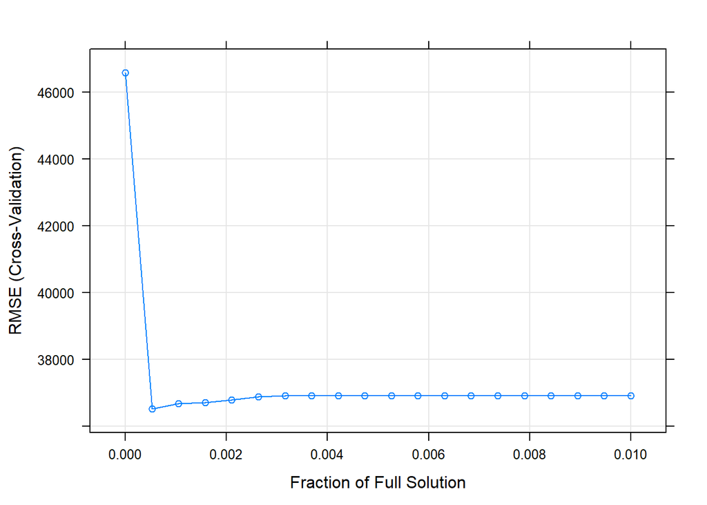

```r
lambdas <- expand.grid(fraction = seq(0.01, 10^-8, length=20))
lassoModel <- train(votos ~ media_despesa + total_despesa + quantidade_fornecedores + quantidade_despesas + recursos_de_partido_politico + recursos_proprios + recursos_de_pessoas_juridicas + recursos_de_pessoas_fisicas + comites + media_receita + total_receita + quantidade_doadores + quantidade_doacoes, data = dadosFiltrados,
                 method = "lasso",
                 tuneGrid = lambdas,
                 preProc = c("center", "scale"),
                 trControl = crossValidation)

plot(lassoModel)
```

```r
lassoModel
```

```
## The lasso
##
## 7476 samples
##   13 predictor
##
## Pre-processing: centered (13), scaled (13)
## Resampling: Cross-Validated (10 fold)
## Summary of sample sizes: 6728, 6728, 6729, 6729, 6728, 6728, ...
## Resampling results across tuning parameters:
##
##   fraction      RMSE      Rsquared   MAE
##   0.0000000100  46590.01  0.4099337  28622.60
##   0.0005263253  36515.75  0.4125492  18898.28
##   0.0010526405  36683.20  0.4078099  17089.61
##   0.0015789558  36718.33  0.4083591  16881.25
##   0.0021052711  36793.86  0.4071664  16859.49
##   0.0026315863  36879.09  0.4058210  16855.31
##   0.0031579016  36911.87  0.4053444  16855.80
##   0.0036842168  36912.16  0.4053351  16856.10
##   0.0042105321  36912.46  0.4053252  16856.39
##   0.0047368474  36912.78  0.4053146  16856.68
##   0.0052631626  36913.12  0.4053034  16856.97
##   0.0057894779  36913.48  0.4052916  16857.26
##   0.0063157932  36913.86  0.4052790  16857.55
##   0.0068421084  36914.25  0.4052659  16857.85
##   0.0073684237  36914.67  0.4052521  16858.14
##   0.0078947389  36915.11  0.4052377  16858.43
##   0.0084210542  36915.57  0.4052226  16858.72
##   0.0089473695  36916.04  0.4052069  16859.01
##   0.0094736847  36916.54  0.4051905  16859.30
##   0.0100000000  36917.06  0.4051735  16859.60
##
## RMSE was used to select the optimal model using the smallest value.
## The final value used for the model was fraction = 0.0005263253.
```

### 3) Modelo KNN

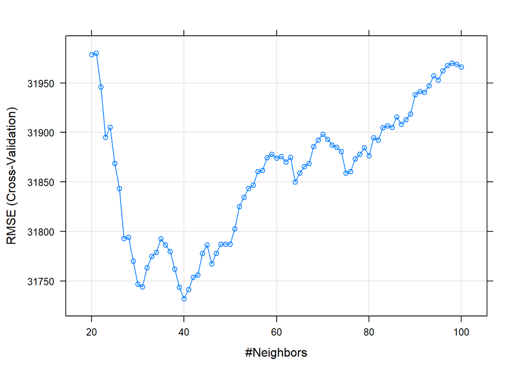

```r
k <- expand.grid(k = seq(20, 100, length=81))

knnModel <- train(votos ~ media_despesa + total_despesa + quantidade_fornecedores + quantidade_despesas + recursos_de_partido_politico + recursos_proprios + recursos_de_pessoas_juridicas + recursos_de_pessoas_fisicas + comites + media_receita + total_receita + quantidade_doadores + quantidade_doacoes,
                     data = dadosFiltrados,
                     method = "knn",
                     trControl = crossValidation,
                     preProcess = c("center","scale"),
                     tuneGrid = k)

plot(knnModel)
```

```r
knnModel
```

```
## k-Nearest Neighbors
##
## 7476 samples
##   13 predictor
##
## Pre-processing: centered (13), scaled (13)
## Resampling: Cross-Validated (10 fold)
## Summary of sample sizes: 6728, 6728, 6729, 6728, 6729, 6730, ...
## Resampling results across tuning parameters:
##
##   k    RMSE      Rsquared   MAE
##    20  31978.69  0.5516817  12010.69
##    21  31980.36  0.5516123  12013.34
##    22  31945.91  0.5526473  11996.98
##    23  31895.22  0.5542573  11972.88
```

[output cut: 80 more lines]

### Questão 2: Compare os três modelos em termos do erro RMSE de validação cruzada.

A partir da questão 1, pode-se afimar que o modelo KNN possui o menor valor de RMSE, seguido pelo modelo Lasso e por fim o modelo Ridge.

### Questão 3: Quais as variáveis mais importantes segundo o modelo de regressão Ridge e Lasso? Variáveis foram descartadas pelo Lasso? Quais?

Para o modelo Ridge as variáveis mais importantes foram as seguintes:

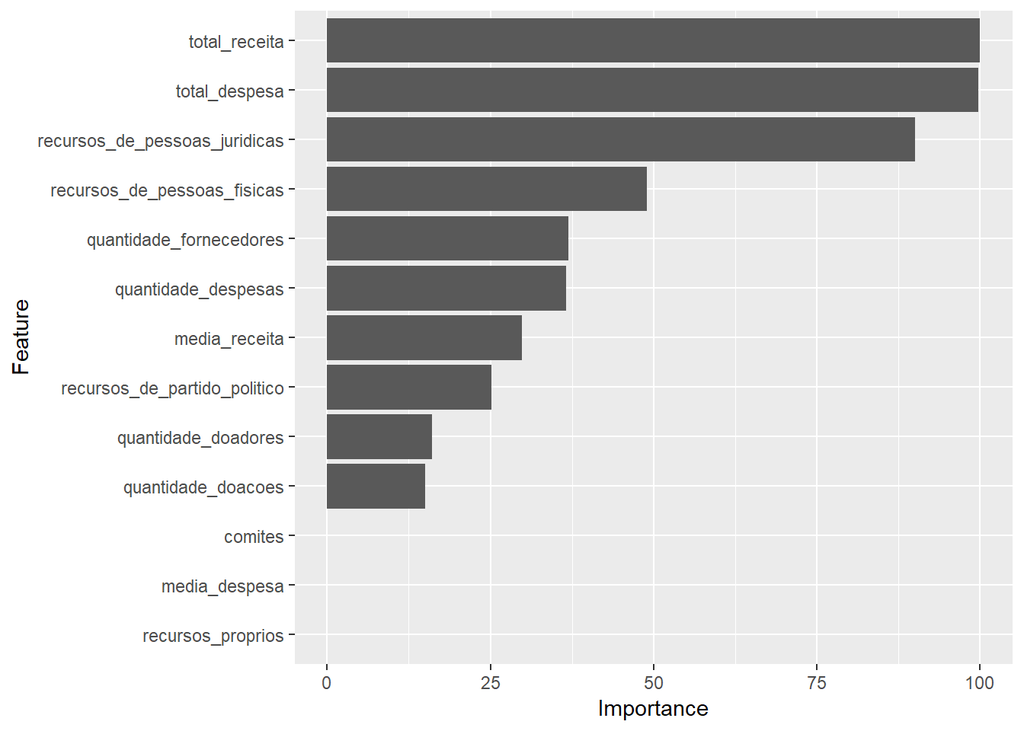

```r
ggplot(varImp(ridgeModel))
```

Enquanto para o modelo Lasso:

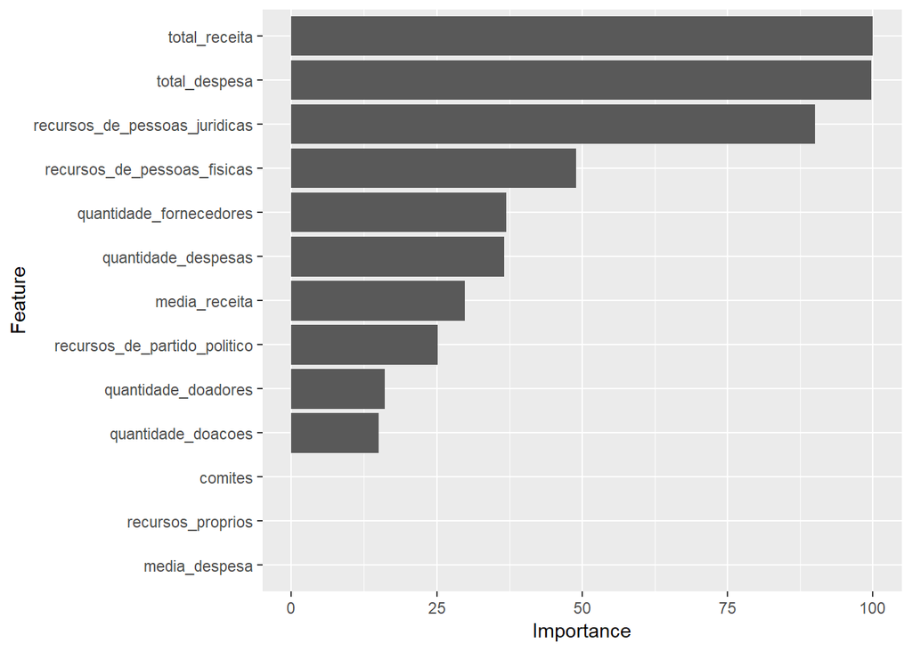

```r
ggplot(varImp(lassoModel))
```

No modelo Lasso, várias variáveis foram descartadas, apenas recursos_de_pessoas_fisicas, recursos_de_pessoas_juridicas e total_despesa permaneceram no modelo.

### Questão 4: Re-treine o melhor modelo (usando os melhores valores de parâmetros encontrados em todos os dados, sem usar validação cruzada)

Nesta questão utilizarei o modelo KNN, pois entre os modelos testados, este mostrou os melhores valores para RMSE.

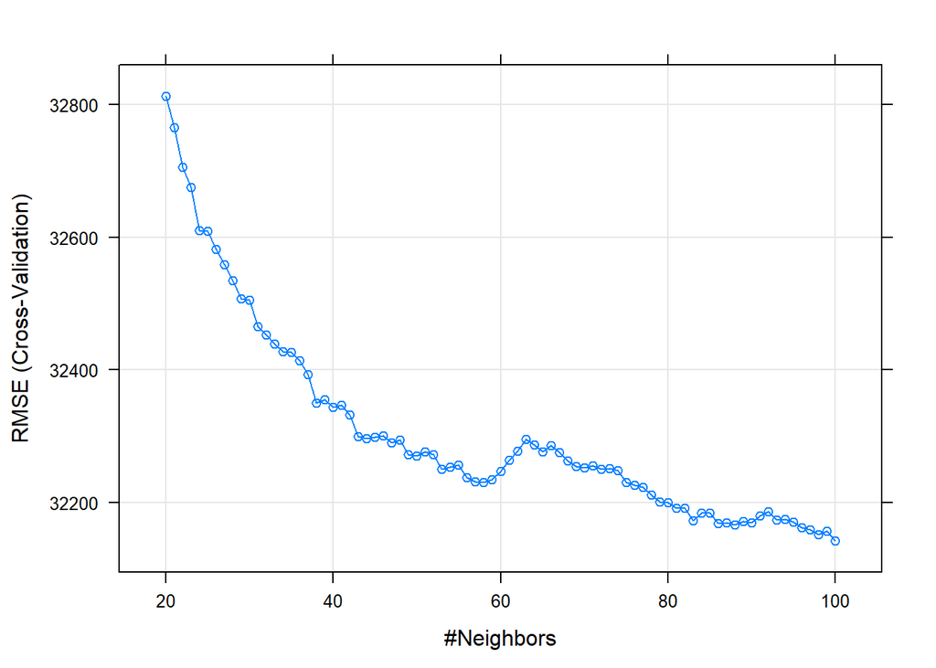

```r
bestVariables <- predictors(lassoModel)
adapData <- dadosFiltrados %>%
  select(bestVariables, votos)
bestKnn <- train(votos ~ .,
                     data = adapData,
                     method = "knn",
                     trControl = crossValidation,
                     preProcess = c("center","scale"),
                     tuneGrid = k)


plot(bestKnn)
```

```r
bestKnn
```

```
## k-Nearest Neighbors
##
## 7476 samples
##    3 predictor
##
## Pre-processing: centered (3), scaled (3)
## Resampling: Cross-Validated (10 fold)
## Summary of sample sizes: 6728, 6729, 6728, 6728, 6730, 6728, ...
## Resampling results across tuning parameters:
##
##   k    RMSE      Rsquared   MAE
##    20  32812.94  0.5276746  12309.59
##    21  32765.52  0.5288481  12273.28
##    22  32705.32  0.5304051  12242.56
##    23  32674.91  0.5310815  12224.64
```

[output cut: 80 more lines]

```r
predict <- predict(bestKnn, teste)
result <- data.frame(ID= teste$sequencial_candidato, votos= predict)
result$ID <- as.character(result$ID)
result %>% write_csv(path = "resultout.csv")
```